# DS4B - Part 2 Frog Species

Heyue WU_u7628175

15/09/2023

# **1. Location on GitHub**

https://github.com/AdriaWu/DS4B-short-report-1//blob/main/DS4B-short-report-1/Part_2_Frog_Species.Rmd

# **2. Loading the data**

```r
# Load necessary R packages
library(tidyverse)
```

```r
library(ggplot2)
library(readxl)
library(dplyr)
library(lubridate)
# Read data from Excel file
data_2 <- read_csv("raw_data/FrogID4_final_dataset.csv")
# have a quick view of the data
tibble(data_2)
```

```
## # A tibble: 484,227 × 21
##    datas…¹ basis…² dataG…³ occur…⁴ sex   lifes…⁵ behav…⁶ sampl…⁷ country machi…⁸
##    <chr>   <chr>   <chr>     <dbl> <chr> <chr>   <chr>   <chr>   <chr>   <chr>
##  1 FrogID  Occurr… Georef…       1 male  adult   calling call r… Austra… An occ…
##  2 FrogID  Occurr… Georef…       2 male  adult   calling call r… Austra… An occ…
##  3 FrogID  Occurr… Georef…       3 male  adult   calling call r… Austra… An occ…
##  4 FrogID  Occurr… Georef…       4 male  adult   calling call r… Austra… An occ…
##  5 FrogID  Occurr… Georef…       5 male  adult   calling call r… Austra… An occ…
##  6 FrogID  Occurr… Georef…       6 male  adult   calling call r… Austra… An occ…
##  7 FrogID  Occurr… Georef…       7 male  adult   calling call r… Austra… An occ…
##  8 FrogID  Occurr… Georef…       8 male  adult   calling call r… Austra… An occ…
##  9 FrogID  Occurr… Georef…       9 male  adult   calling call r… Austra… An occ…
## 10 FrogID  Occurr… Georef…      10 male  adult   calling call r… Austra… An occ…
## # … with 484,217 more rows, 11 more variables: eventID <dbl>,
## #   decimalLatitude <dbl>, decimalLongitude <dbl>, scientificName <chr>,
## #   eventDate <date>, eventTime <chr>, coordinateUncertaintyInMeters <dbl>,
## #   geoprivacy <chr>, recordedBy <dbl>, stateProvince <chr>, modified <date>,
## #   and abbreviated variable names ¹datasetName, ²basisOfRecord,
## #   ³dataGeneralizations, ⁴occurrenceID, ⁵lifestage, ⁶behavior,
## #   ⁷samplingProtocol, ⁸machineObservation
```

```r
# Check the type of value
summary(data_2)
```

```
##  datasetName        basisOfRecord      dataGeneralizations  occurrenceID
##  Length:484227      Length:484227      Length:484227       Min.   :     1
##  Class :character   Class :character   Class :character    1st Qu.:121058
##  Mode  :character   Mode  :character   Mode  :character    Median :242114
##                                                            Mean   :242114
##                                                            3rd Qu.:363171
##                                                            Max.   :484227
##      sex             lifestage           behavior         samplingProtocol
##  Length:484227      Length:484227      Length:484227      Length:484227
##  Class :character   Class :character   Class :character   Class :character
##  Mode  :character   Mode  :character   Mode  :character   Mode  :character
##
##
##
##    country          machineObservation    eventID       decimalLatitude
##  Length:484227      Length:484227      Min.   :  2831   Min.   :-43.609
##  Class :character   Class :character   1st Qu.: 85600   1st Qu.:-35.180
##  Mode  :character   Mode  :character   Median :160881   Median :-33.325
##                                        Mean   :159581   Mean   :-31.170
##                                        3rd Qu.:229180   3rd Qu.:-28.798
##                                        Max.   :556831   Max.   : -9.416
##  decimalLongitude scientificName       eventDate           eventTime
##  Min.   :113.5    Length:484227      Min.   :2017-11-10   Length:484227
##  1st Qu.:145.1    Class :character   1st Qu.:2019-10-15   Class :character
##  Median :149.8    Mode  :character   Median :2020-10-10   Mode  :character
##  Mean   :145.4                       Mean   :2020-06-14
##  3rd Qu.:151.4                       3rd Qu.:2021-03-22
##  Max.   :153.6                       Max.   :2021-11-09
##  coordinateUncertaintyInMeters  geoprivacy          recordedBy
##  Min.   :-2147480.0            Length:484227      Min.   :    19
##  1st Qu.:       5.0            Class :character   1st Qu.:  7906
##  Median :      10.0            Mode  :character   Median : 15985
##  Mean   :     550.9                               Mean   : 53948
##  3rd Qu.:      48.0                               3rd Qu.: 28617
##  Max.   : 1445600.0                               Max.   :836365
##  stateProvince         modified
##  Length:484227      Min.   :2023-05-29
##  Class :character   1st Qu.:2023-05-29
##  Mode  :character   Median :2023-05-29
##                     Mean   :2023-05-29
##                     3rd Qu.:2023-05-29
##                     Max.   :2023-05-29
```

# **3. Data Cleaning and Preliminary Analysis**

The next step is to identify any anomalies, inconsistencies, or missing values.

## 3.1. Check for missing values

```r
# Use the `summarise_all()` to summarize or calculate all columns in a data frame (written by ChatGPT)
data_2 |>
  summarise_all(~sum(is.na(.)))
```

```
## # A tibble: 1 × 21
##   datase…¹ basis…² dataG…³ occur…⁴   sex lifes…⁵ behav…⁶ sampl…⁷ country machi…⁸
##      <int>   <int>   <int>   <int> <int>   <int>   <int>   <int>   <int>   <int>
## 1        0       0       0       0     0       0       0       0       0       0
## # … with 11 more variables: eventID <int>, decimalLatitude <int>,
## #   decimalLongitude <int>, scientificName <int>, eventDate <int>,
## #   eventTime <int>, coordinateUncertaintyInMeters <int>, geoprivacy <int>,
## #   recordedBy <int>, stateProvince <int>, modified <int>, and abbreviated
## #   variable names ¹datasetName, ²basisOfRecord, ³dataGeneralizations,
## #   ⁴occurrenceID, ⁵lifestage, ⁶behavior, ⁷samplingProtocol,
## #   ⁸machineObservation
```

This means that all rows of these columns have valid data, with no missing values.

## 3.2. Check for duplicates

We can check whether there is any repeated recording for `occurrenceID` as it is a unique identifier for each record (Rowley, J. J, 2020)

```r
# use the `duplicated()` function to identify and count duplicate rows.
duplicates_by_occurrenceID <- sum(duplicated(data_2$occurrenceID))
duplicates_by_occurrenceID
```

```
## [1] 0
```

Okay. There are no duplicate `occurrenceID` so maybe we can trust that there are no duplicate records.

## 3.3. Check for Inconsistencies

```r
# Check the 'basisOfRecord' column
inconsistent_basisOfRecord <- sum(data_2$basisOfRecord != "Occurrence")

# Check whether all rows are recorded by adult and male frogs
non_adult_male_rows <- sum(data_2[!(data_2$sex == "male" & data_2$lifestage == "adult"), ])

inconsistent_basisOfRecord
```

```
## [1] 0
```

```r
non_adult_male_rows
```

```
## [1] 0
```

Thus, all records are consistently marked as ‘Occurrence’ and only adult male frogs are recorded in the data.

## 3.4. Provide a summary of the dataset

Before diving into any analysis or visualization, we can make a summary of the dataset to provide a quick snapshot of key features for the data, which might help the readers who are unfamiliar with the dataset.

```r
# Number of unique species
unique_species <- length(unique(data_2$scientificName))

# Get range of dates

# The original date data is in character format, and we can just find the start date and end date.
start_Date <- as.character(min(data_2$eventDate))
end_Date <- as.character(max(data_2$eventDate))

# Distribution of recordings across states
state_distribution <- table(data_2$stateProvince)

# Print the summary
cat("Summary of the Dataset:\n",
    "-----------------------\n",
    "Number of Unique Species Recorded:", unique_species, "\n",
    "Range of Dates: From", start_Date, "to", end_Date, "\n",
    "Distribution of Recordings Across States:\n"
    )
```

```
## Summary of the Dataset:
##  -----------------------
##  Number of Unique Species Recorded: 199
##  Range of Dates: From 2017-11-10 to 2021-11-09
##  Distribution of Recordings Across States:
```

```r
print(state_distribution)
```

```
##
##               ACT               NSW                NT Other Territories
##              8633            229000             25330                99
##               QLD                SA               TAS               VIC
##             84731              9615              6697             75820
##                WA
##             44302
```

We can know that the dataset has recorded a total of **199** unique species. The recordings span from the date 2017-11-10 to 2021-11-09. And with 229,000 recordings, NSW dominates the dataset, accounting for a significant portion of the total recordings.

# **4. Plot the species discovery curve for Australia**

## 4.1. Plot the species discovery curve for the whole of Australia

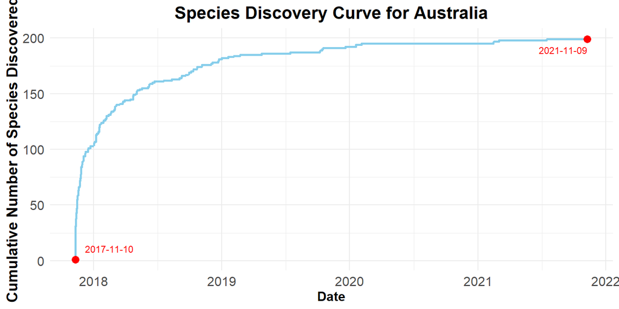

```r
# Convert into Date objects and create a new column to store them.
data_2$Date_Object <- as.Date(data_2$eventDate, format="%Y/%m/%d")

# Sort the data by date
data_sorted <- data_2 |>
  arrange(Date_Object) |>
  # Calculate the cumulative number of species discovered so far. But it can't include previously duplicated species (written by ChatGPT).
  mutate(cumulative_species = cumsum(!duplicated(scientificName)))

# Plot the species discovery curve for Australia as whole
plot_1 <- ggplot(data_sorted, aes(x = Date_Object, y = cumulative_species)) +
  geom_line(color = "skyblue", linewidth = 1) +

  labs(title = "Species Discovery Curve for Australia",
       x = "Date",
       y = "Cumulative Number of Species Discovered") +
  theme_minimal() +
  theme(
    plot.title = element_text(hjust = 0.5, size = 16, face = "bold"),
    axis.title.x = element_text(size = 12, face = "bold"),
    axis.title.y = element_text(size = 14, face = "bold"),
    axis.text.x = element_text(size = 12),
    axis.text.y = element_text(size = 12),
    )

# Extract the first and last dates of the data_sorted
first_date <- data_sorted[1, ]
last_date <- data_sorted[nrow(data_sorted), ]

# Add points and date labels
plot_1 <- plot_1 +
  geom_point(data = first_date, aes(x = Date_Object, y = cumulative_species), color = "red", size = 3) +
  geom_point(data = last_date, aes(x = Date_Object, y = cumulative_species), color = "red", size = 3) +
  geom_text(data = first_date,
            aes(x = Date_Object,
                y = cumulative_species,
                label = start_Date),
            vjust = -1,
            hjust = -0.2,
            size = 3,
            color = "red") +
  geom_text(data = last_date,
            aes(x = Date_Object,
                y = cumulative_species,
                label = end_Date),
            vjust = 2,
            hjust = 1,
            size = 3,
            color = "red")

print(plot_1)
```

From plot 1, we can see that by the date 2021-11-09, the cumulative number of species discovered was close to 200.

## 4.2. Plot the data for each state and territory

Next, let’s use different colors to represent each state on the same plot to show the same relationship for each state and territory.

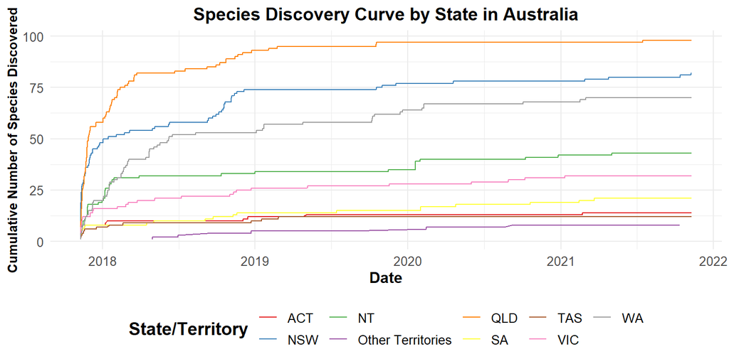

```r
# Sort and group data by date and state
data_sorted_statewise <- data_2 |>
  arrange(Date_Object) |>
  group_by(stateProvince) |>
  mutate(cumulative_species = cumsum(!duplicated(scientificName)))

# Plot the species discovery curve for each state
plot_2 <- ggplot(data_sorted_statewise,
                 aes(x = Date_Object,
                     y = cumulative_species,
                     color = stateProvince)) +
  geom_line() +
  # Use the "Set1" color palette to set colors for different states
  scale_color_brewer(palette = "Set1") +
  labs(title = "Species Discovery Curve by State in Australia",
       x = "Date",
       y = "Cumulative Number of Species Discovered",
       color = "State/Territory") +
  theme_minimal() +
  theme(
    plot.title = element_text(hjust = 0.5, size = 14, face = "bold"),
    axis.title.x = element_text(size = 12, face = "bold"),
    axis.title.y = element_text(size = 10, face = "bold"),
    axis.text.x = element_text(size = 10),
    axis.text.y = element_text(size = 10),
    # Set the position of the legend at the bottom for better view
    legend.position = "bottom",
    legend.title = element_text(size = 14, face = "bold"),
    legend.text = element_text(size = 10)
  )

print(plot_2)
```

# **5. Estimation of True Number of Frog Species**

Now we need to estimate the true number of frog species in Australia in two ways. One is the extrapolation emthod, and another is the Chao1 method.

## 5.1. Extrapolation Method

We can fit a curve (e.g., logistic growth curve) to the Australia-wide species discovery data. Extrapolate this curve to estimate when it levels off, indicating the potential total number of species.

After searching on **Wikipedia**, we can get the equation of the logistic growth curve:

$$N(t) = \frac{K}{1 + \frac{K - N_0}{N_0} e^{-rt}}$$

Where:

- $N(t)$ is the number of species discovered up to time $t$.
- $K$ is the carrying capacity, or the total number of species.
- $r$ is the growth rate.
- $N_0$ is the initial number of species at $t = 0$.

We have sorted the data by date and has a cumulative count of species discovered up to each date before. Next, the **ChatGPT** tells us that we can use the `nls()` function (nonlinear least square method) in R to fit the logistic growth curve to the data. Then use the fitted model to predict the total number of species.

```r
# Fit the logistic growth curve (written by ChatGPT)

model <- nls(cumulative_species ~ K / (1 + ((K - N0) / N0) * exp(-r * as.numeric(Date_Object - min(Date_Object)))),
             data = data_sorted,
             # Provide initial estimates to begin the iterative process
             start = list(K = max(data_sorted$cumulative_species) * 2,
                          N0 = data_sorted$cumulative_species[1],
                          r = 0.01)
             )

# Extract the estimated K (carrying capacity) which represents the total number of species (written by ChatGPT).
K_estimate <- coef(model)["K"]

# Print the estimated number of species and rounding up estimates to make it easier to read.
print(paste("Estimated Total Number of Frog Species:", round(K_estimate)))
```

```
## [1] "Estimated Total Number of Frog Species: 196"
```

Based on this model, the estimated total number of frog species in Australia is **196**.

## 5.2. Chao1 Method

The Chao1 estimator is a popular method to estimate species richness. The formula for Chao1 which I asked from *ChatGPT* is:

$$Chao1 = S_{obs} + \frac{n_1(n_1 - 1)}{2(n_2 + 1)}$$

Where:

- $S_{obs}$ is the number of observed species.
- $n_1$ is the number of species observed exactly once (singletons).
- $n_2$ is the number of species observed exactly twice (doubletons).

In Chao1 method, the presence of many rare species which are observed only once or twice, suggests that many species have not been observed at all.

```r
# Count the number of occurrences for each species
species_counts <- table(data_2$scientificName)

# Calculate the number of singletons and doubletons
n_1 <- sum(species_counts == 1)
n_2 <- sum(species_counts == 2)

# Calculate Chao1 estimate
S_obs <- length(unique(data_2$scientificName))
Chao1 <- S_obs + (n_1 * (n_1 - 1)) / (2 * (n_2 + 1))

# For 95% confidence intervals, we use the variance formula for Chao1
var_Chao1 <- S_obs + (n_1 * (n_1 - 1)) / (2 * (n_2 + 1))^2 * (2 * n_1 - 1) + n_1^2 / (n_2 + 1)
# Use the standard normal distribution method to calculate the 95% confidence interval. Here 1.96 is the Z-score of the normal distribution, corresponding to the 95% confidence interval (written by ChatGPT).
lower_95 <- Chao1 - 1.96 * sqrt(var_Chao1)
upper_95 <- Chao1 + 1.96 * sqrt(var_Chao1)

print(paste("Chao1 estimate:", round(Chao1)))
```

```
## [1] "Chao1 estimate: 202"
```

```r
print(paste("95% CI: [", round(lower_95), ",", round(upper_95), "]"))
```

```
## [1] "95% CI: [ 174 , 230 ]"
```

Using this method, we predict a total of **202** species. Furthermore, the 95% confidence interval ranges from 174 to 230. This means we are 95% confident that the true number of species lies within this range.

## 5.3 Visualization on the species discovery curve

Now we can visualize this on the species discovery curve for Australia, marking the estimates and the best-guess number.

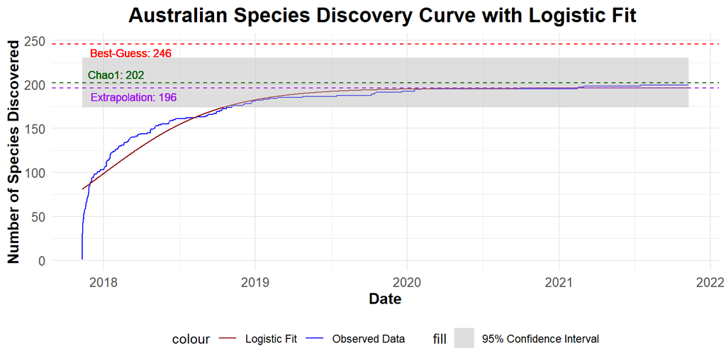

```r
# To visualize the fit and extrapolation
data_sorted$predicted_species <- predict(model, newdata = data_sorted)

plot_3 <- ggplot(data_sorted, aes(x = Date_Object)) +
  geom_line(aes(y = cumulative_species, color = "Observed Data")) +
  geom_line(aes(y = predicted_species, color = "Logistic Fit")) +
  labs(title = "Australian Species Discovery Curve with Logistic Fit ",
       x = "Date",
       y = "Number of Species Discovered") +
  theme_minimal() +
  theme(
    plot.title = element_text(hjust = 0.5, size = 16, face = "bold"),
    axis.title.x = element_text(size = 12, face = "bold"),
    axis.title.y = element_text(size = 12, face = "bold"),
    axis.text.x = element_text(size = 10),
    axis.text.y = element_text(size = 10),
    legend.position = "bottom",
  ) +
  scale_color_manual(values = c("Observed Data" = "blue", "Logistic Fit" = "darkred"))

# Visualize the 95% confidence interval ranges for Chao1 method

# Add upper and lower confidence intervals
data_sorted$lower_95 <- lower_95
data_sorted$upper_95 <- upper_95

# Add filling of confidence intervals (written by ChatGPT)
plot_3 <- plot_3 +
  geom_ribbon(aes(ymin = lower_95, ymax = upper_95, fill = "95% Confidence Interval"), alpha = 0.5) +
  scale_fill_manual(values = c("95% Confidence Interval" = "grey"))

# Add horizontal lines for the estimates and best-guess number
plot_3 <- plot_3 +
  geom_hline(yintercept = 196, color = "purple", linetype = "dashed") +
  geom_hline(yintercept = 202, color = "darkgreen", linetype = "dashed") +
  geom_hline(yintercept = 246, color = "red", linetype = "dashed") +
  geom_text(aes(x = min(Date_Object), y = 196, label = "Extrapolation: 196"),
            hjust = -0.1, vjust = 1.5, color = "purple", size = 3) +
  geom_text(aes(x = min(Date_Object), y = 202, label = "Chao1: 202"),
            hjust = -0.1, vjust = -0.5, color = "darkgreen", size = 3) +
  geom_text(aes(x = min(Date_Object), y = 246, label = "Best-Guess: 246"),
            hjust = -0.1, vjust = 1.5, color = "red", size = 3)

print(plot_3)
```

# **6. Comparison with Best-Guess Number**

Based on the above code and calculation, we get the following results:

- The Extrapolation Method gave us an estimate of 196 species.
- The Chao1 estimation method predicted 202 species.

Both methods provided estimates that are lower than the best-guess number.

**Discussion**

We will discuss potential reasons for discrepancies between the estimates and the best-guess number. Factors like the inherent limitations of the estimation methods, sampling bias, the geographical distribution of recordings, and seasonality can be considered.

1. **Inherent Limitations of Estimation Methods**:
- *Extrapolation Method*: This method assumes that the rate of species discovery will continue in the same pattern as observed. However, as more species are discovered, the rate of new discoveries might slow down, leading to an underestimation (Carneiro, L., 2016).
- *Chao1 Method*: This method heavily relies on the number of singletons and doubletons. If there’s a high number of rarely observed species, the estimate might be skewed. Additionally, it assumes that species are randomly sampled, which might not be the case due to the reasons mentioned above (Béguinot, J., 2015).
2. **Sampling Bias**: The data might not be uniformly sampled across all regions of Australia. Some areas might be over-represented, while others might be under-represented. This can lead to an underestimation of species diversity, especially if certain regions with unique species were not adequately sampled.
3. **Geographical Distribution of Recordings**: If the recordings are predominantly from urban or easily accessible areas, many species from remote or less accessible regions might be missed. Australia’s vast landscapes and diverse habitats can host a variety of species, some of which might not have been captured in the dataset（Amboni, M.P. & Laffan, S.W., 2012).
4. **Seasonality**: Frogs are often more vocal and active during certain seasons, especially the breeding season. If recordings were predominantly from off-peak seasons, some species might not have been detected.

In conclusion, while both the Extrapolation and Chao1 methods provide valuable insights into species diversity, they have their limitations and assumptions. It’s essential to consider these factors and the context of the data collection when interpreting the results. The best-guess number, derived from in-depth taxonomic and genetic studies, remains the most comprehensive estimate, but the other methods can offer quick insights when such detailed studies are not feasible.

# **References**

Amboni, M.P., & Laffan, S.W. (2012). The effect of species geographical distribution estimation methods on richness and phylogenetic diversity estimates. *International Journal of Geographical Information Science*, 26, 2097 - 2109.

Béguinot, J. (2015). Extrapolation of the Species Accumulation Curve for Incomplete Species Samplings: A New Nonparametric Approach to Estimate the Degree of Sample Completeness and Decide when to Stop Sampling. *Annual research & review in biology*, 8, 1-9.

Carneiro, L., Lima, A.P., Machado, R.B., & Magnusson, W.E. (2016). Limitations to the Use of Species-Distribution Models for Environmental-Impact Assessments in the Amazon. *PLoS ONE*, 11.

OpenAI. (2023). ChatGPT (Version 4.0). OpenAI. https://www.openai.com/

Rowley, J. J., Callaghan, C. T., Cutajar, T., Portway, C., Potter, K., Mahony, S., … & Woods, A. (2019). FrogID: Citizen scientists provide validated biodiversity data on frogs of Australia. *Herpetological Conservation and Biology*, 14(1), 155-170.

Rowley, J. J. L., & Callaghan, C. T. (2020). The FrogID dataset: expert-validated occurrence records of Australia’s frogs collected by citizen scientists. *ZooKeys*, 912, 139–151. https://doi.org/10.3897/zookeys.912.38253

Wikipedia contributors. (2023, September 5). Logistic function. In Wikipedia, *The Free Encyclopedia*. Retrieved 10:50, September 20, 2023, from https://en.wikipedia.org/w/index.php?title=Logistic_function&oldid=1173943856